# Modeling life expectancy with lifeplus

```r
library(lifeplus)
library(ggplot2)
```

## Introduction

The `lifeplus` package allows you to fit a variety of Bayesian hierarchical models to life expectancy data. The models are modular, allowing you to mix and match multiple types of model components (Susmann, Alexander, and Alkema 2022).

### The model

Let $c = 1, \dots, C$ index the areas (typically countries) and $t = 1, \dots, T$ index time points (typically years). Let $y_{c,t}$ be the observed life expectancy at birth in area $c$ at time $t$. The core of the model is the following equation:

$$y_{c,t} = y_{c,t-1} + g\left(y_{c,t-1}, \beta_c\right) + \delta_{c,t} +
\epsilon_{c,t}$$

where

- $g(\cdot)$ is a **transition function** that models the expected rate of change of the outcome as a function of its previous level, using area-specific parameters $\beta_c$. This term captures long-term, systematic trends in life expectancy.
- $\delta_{c,t}$ is a **shock term** representing large departures from the overall trend.
- $\epsilon_{c,t}$ is a **residual** capturing short-term departures from the overall trend, which we model with a data model.

Each of these three components can be configured independently. For full details on the available options, see the documentation for each constructor (e.g, `?transition_model_double_logistic`).

### Transition models

- **Double logistic**: `transition_model_double_logistic`. The transition is modeled by a parametric double logistic function (Raftery et al. 2013).
- **Spline**: `transition_model_spline`. The transition is modeled by a B-spline function.
- **Gaussian Process**: `transition_model_gaussian_process`. The transition function is assigned a Gaussian Process prior, approximated using a basis function expansion method (Riutort-Mayol et al. 2023).

All transition models support a `hierarchical` option that enables partial pooling of transition parameters across areas.

### Shock models

- **None**: `shock_model_none`. All shock terms are fixed to zero: $\delta_{c,t} = 0$.
- **Regularized horseshoe**: `shock_model_regularized_horseshoe`. Sparse shrinkage prior that allows a small number of large shocks (Piironen and Vehtari 2017).

### Data models

- **Normal**: `data_model_normal`. The residuals are modeled as $\epsilon_{c,t} \sim N\left(0, \sigma^2\right)$.
- **Outlier**: `data_model_outlier`. Observations with absolute differences exceeding a threshold are excluded; remaining residuals are normal.

## World Population Prospect Data

We use male life expectancy estimates from the [United Nations World Population Prospects 2024](https://population.un.org/wpp/), available through the [`wpp2024`](https://github.com/PPgp/wpp2024) R package.

We’ll work with Bosnia and Herzegovina as an initial example.

```r
library(wpp2024)
data(UNlocations, package = "wpp2024")
data(e0M1, package = "wpp2024")

bosnia_herzegovina_codes <- UNlocations |>
  dplyr::filter(name == "Bosnia and Herzegovina") |>
  dplyr::pull(country_code)

bosnia_herzegovina <- e0M1 |>
  dplyr::filter(country_code %in% bosnia_herzegovina_codes) |>
  tidyr::pivot_longer(
    cols = `1950`:`2023`,
    names_to = "year",
    values_to = "e0"
  ) |>
  dplyr::mutate(year = as.numeric(year))
```

[figure not shown]

```r
ggplot(data, aes(x = year, y = e0)) +
  geom_point() +
  labs(
    x = "Year",
    y = "Male life expectancy at birth (e0)",
    title = "Bosnia and Herzegovina"
  )
```

## Fitting a basic model

Before fitting models, let’s define a wrapper with shared sampling settings. This helps us keep the examples concise, and ensures we use the same MCMC settings across all the models we fit:

```r
my_lifeplus <- function(data, ...) {
  lifeplus(
    data = data,
    y = "e0",
    time = "year",
    area = "name",
    end_time = 2050,
    iter_warmup = 1e3,
    iter_sampling = 1e3,
    refresh = 0,
    show_messages = FALSE,
    show_exceptions = FALSE,
    parallel_chains = 4,
    adapt_delta = 0.99,
    ...
  )
}
```

We start with a simple configuration: a double logistic transition model, normal data model, and no shock terms. As we’re fitting a single country, hierarchical estimation across areas is not applicable, so we set `hierarchical = FALSE`:

```r
fit_basic <- my_lifeplus(
  data = bosnia_herzegovina,
  transition_model = transition_model_double_logistic(hierarchical = FALSE),
  data_model = data_model_normal(),
  shock_model = shock_model_none()
)
```

```
#> Extracting posteriors...
```

The `print` method gives a quick overview of the fit:

```r
print(fit_basic)
```

```
#> ── lifeplus model fit ──────────────────────────────────────────────────────────────────────────────────────────────────────────────
#>
#> ── Data
#> • Outcome variable: e0
#> • Time variable: year (1950 to 2050)
#> • Area variable: name (1 areas)
#> • Observations: 74 (0 held out)
#>
#> ── Model components
#>   • Transition: double_logistic
#>   • Data: normal
#>   • Shock: none
#>
#> ── Sampling
#>   • Chains: 4
#>   • Iterations: 1000 warmup + 1000 sampling
#>   • Elapsed: 3.92 secs
#>
#> ── Diagnostics
#> ✔ No divergent transitions
#> ✔ No max treedepth warnings
#> ✔ No E-BFMI warnings
```

We can examine posterior summaries with `summary`. Here are the projected estimates for 2024-2030:

```r
summary(fit_basic, times = 2024:2030)
```

```
#> ── lifeplus summary ────────────────────────────────────────────────────────────────────────────────────────────────────────────────
#> 1 area, 7 time points
#>
#> ── Posterior summaries (life)
#> # A tibble: 7 × 17
#>   variable `0.1%`  `1%` `2.5%` `10%` `25%` `50%` `75%` `90%` `97.5%` `99%` `99.9%`  rhat ess_bulk ess_tail area                 time
#>   <chr>     <dbl> <dbl>  <dbl> <dbl> <dbl> <dbl> <dbl> <dbl>   <dbl> <dbl>   <dbl> <dbl>    <dbl>    <dbl> <chr>               <dbl>
#> 1 eta        64.5  67.1   68.1  70.3  72.3  74.6  76.9  78.8    80.9  82.0    84.7 1.000    4218.    3756. Bosnia and Herzego…  2024
#> 2 eta        60.8  64.1   65.6  68.8  71.8  74.9  78.0  80.8    84.0  85.4    89.3 1.00     3953.    3693. Bosnia and Herzego…  2025
#> 3 eta        58.0  62.1   64.0  67.8  71.2  75.0  78.9  82.4    86.3  88.3    91.5 1.00     3868.    3800. Bosnia and Herzego…  2026
#> 4 eta        56.4  60.3   62.6  66.8  70.7  75.0  79.6  83.8    88.3  90.5    96.1 1.00     4100.    3751. Bosnia and Herzego…  2027
#> 5 eta        54.1  58.7   61.5  66.0  70.3  75.2  80.2  85.0    89.7  92.4    96.4 1.00     4135.    3806. Bosnia and Herzego…  2028
#> 6 eta        51.1  57.3   60.2  65.1  70.0  75.3  80.9  85.9    91.6  93.8   101.  1.00     3941.    3736. Bosnia and Herzego…  2029
#> 7 eta        53.3  56.4   59.0  64.6  69.7  75.5  81.3  87.0    92.9  96.1   102.  1.00     4032.    3809. Bosnia and Herzego…  2030
#>
#> ── Diagnostics
#> ✔ All diagnostics passed
#> ────────────────────────────────────────────────────────────────────────────────────────────────────────────────────────────────────
```

The `plot_projections` function shows the posterior projections overlaid on the observed data:

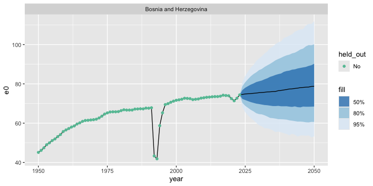

```r
plot_projections(fit_basic, data = TRUE)
```

The `plot_transitions` function shows the estimated transition function (the expected rate of change in male life expectancy as a function of its level):

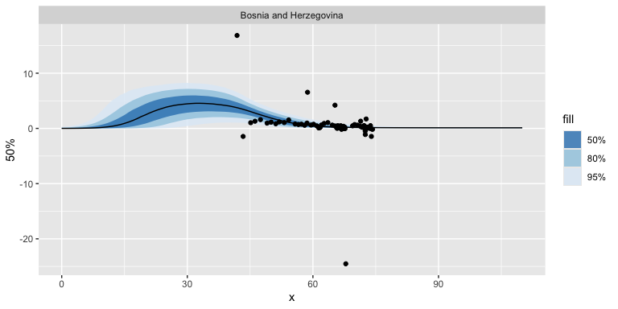

```r
plot_transitions(fit_basic)
```

## Adding shock terms

By adding a regularized horseshoe shock model, we can allow the model attribute large deviations in life expectancy to specific country-years, allowing the underlying transition model to capture longer-term smooth trends.

```r
fit_shocks <- my_lifeplus(
  data = bosnia_herzegovina,
  transition_model = transition_model_double_logistic(hierarchical = FALSE),
  data_model = data_model_normal(),
  shock_model = shock_model_regularized_horseshoe(scale_global = 0.1)
)
```

```
#> Extracting posteriors...
```

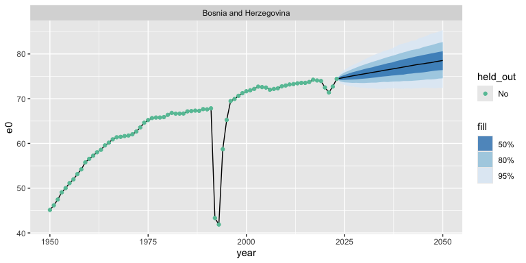

```r
plot_projections(fit_shocks)
```

The estimated shock terms reveal when the model detected large short-term deviations from the expected trend:

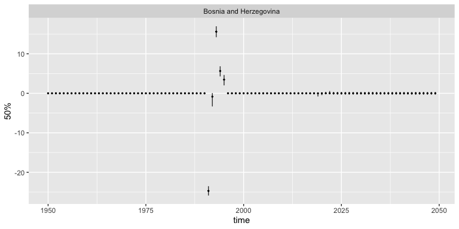

```r
plot_shocks(fit_shocks)
```

The transition function now better captures the shape of the data, and exhibits tighter uncertainty estimates than the basic model without shocks:

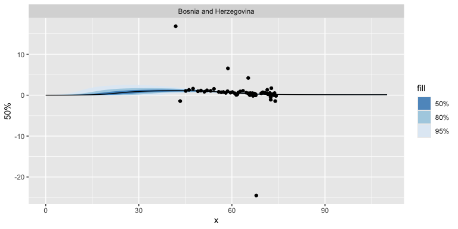

```r
plot_transitions(fit_shocks)
```

## Validating models

We can assess predictive performance by holding out recent data. Setting `cutoff_time = 2015` fits the model using only data up to 2015. We can then evaluate how well the projections match the observed 2016-2023 values:

```r
fit_valid_basic <- my_lifeplus(
  data = bosnia_herzegovina,
  transition_model = transition_model_double_logistic(hierarchical = FALSE),
  data_model = data_model_normal(),
  shock_model = shock_model_none(),
  cutoff_time = 2015
)
```

```
#> Extracting posteriors...
```

```r
fit_valid_shocks <- my_lifeplus(
  data = bosnia_herzegovina,
  transition_model = transition_model_double_logistic(hierarchical = FALSE),
  data_model = data_model_normal(),
  shock_model = shock_model_regularized_horseshoe(scale_global = 0.1),
  cutoff_time = 2015
)
```

```
#> Extracting posteriors...
```

The projection plots automatically distinguish the held-out observations:

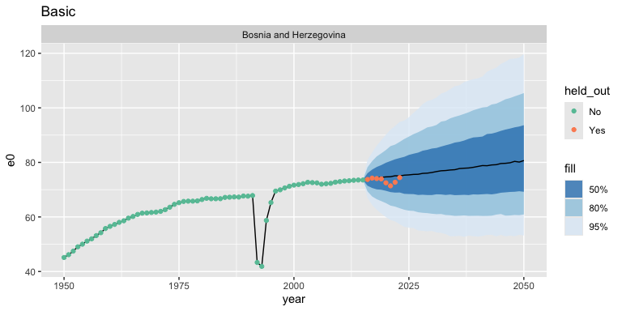

```r
plot_projections(fit_valid_basic, data = TRUE) + ggtitle("Basic")
```

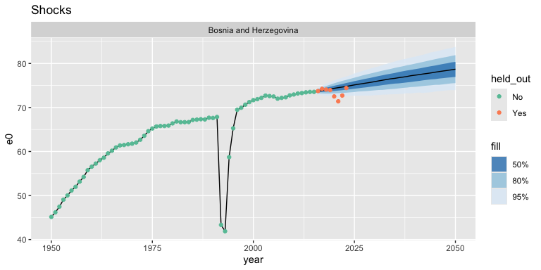

```r
plot_projections(fit_valid_shocks, data = TRUE) + ggtitle("Shocks")
```

The `glance` method returns a one-row tibble with MCMC diagnostics and validation metrics, making it easy to compare models:

```r
dplyr::bind_rows(
  glance(fit_valid_basic) |> dplyr::mutate(model = "basic"),
  glance(fit_valid_shocks) |> dplyr::mutate(model = "shocks")
) |>
  dplyr::select(model, mean_error, ci.width)
```

```
#> # A tibble: 2 × 3
#>   model  mean_error ci.width
#>   <chr>       <dbl>    <dbl>
#> 1 basic      -0.621    37.5
#> 2 shocks     -0.365     4.42
```

The validation results show the models perform similarly in terms of error, but the model that allows for shocks has a much smaller 95% credible interval width. We can drill into this further by looking at the estimated parameters for the residual:

```r
summary(fit_valid_basic, component = "data_params")
```

```
#> ── lifeplus summary ────────────────────────────────────────────────────────────────────────────────────────────────────────────────
#> 1 area, 101 time points
#>
#> ── Posterior summaries (data_params)
#> # A tibble: 1 × 15
#>   variable      `0.1%`  `1%` `2.5%` `10%` `25%` `50%` `75%` `90%` `97.5%` `99%` `99.9%`  rhat ess_bulk ess_tail
#>   <chr>          <dbl> <dbl>  <dbl> <dbl> <dbl> <dbl> <dbl> <dbl>   <dbl> <dbl>   <dbl> <dbl>    <dbl>    <dbl>
#> 1 epsilon_sigma   2.73  2.88   2.96  3.11  3.26  3.44  3.62  3.81    4.02  4.13    4.40  1.00    3589.    2636.
#>
#> ── Diagnostics
#> ✔ All diagnostics passed
#> ────────────────────────────────────────────────────────────────────────────────────────────────────────────────────────────────────
```

```r
summary(fit_valid_shocks, component = "data_params")
```

```
#> ── lifeplus summary ────────────────────────────────────────────────────────────────────────────────────────────────────────────────
#> 1 area, 101 time points
#>
#> ── Posterior summaries (data_params)
#> # A tibble: 1 × 15
#>   variable      `0.1%`  `1%` `2.5%` `10%` `25%` `50%` `75%` `90%` `97.5%` `99%` `99.9%`  rhat ess_bulk ess_tail
#>   <chr>          <dbl> <dbl>  <dbl> <dbl> <dbl> <dbl> <dbl> <dbl>   <dbl> <dbl>   <dbl> <dbl>    <dbl>    <dbl>
#> 1 epsilon_sigma  0.248 0.267  0.279 0.300 0.322 0.348 0.380 0.411   0.450 0.471   0.516  1.00    2825.    2723.
#>
#> ── Diagnostics
#> ✔ All diagnostics passed
#> ────────────────────────────────────────────────────────────────────────────────────────────────────────────────────────────────────
```

The posterior median of the residual standard deviation parameter (`\sigma_\epsilon`) is about 10 times higher in the basic model than the shocks model. Without the shock term, the basic model has to use the residuals to model the large changes in life expectancy, which subsequently drives up the variance of the projections.

## Hierarchical estimation with multiple countries

Hierarchical estimation allows for the transition functions to borrow information across countries. To illustrate, let’s fit a model to multiple East African countries.

```r
east_africa_names <- c("Somalia", "Ethiopia", "Kenya", "Djibouti")
east_africa_codes <- UNlocations |>
  dplyr::filter(name %in% east_africa_names) |>
  dplyr::pull(country_code)

east_africa <- e0M1 |>
  dplyr::filter(country_code %in% east_africa_codes) |>
  tidyr::pivot_longer(
    cols = `1950`:`2023`,
    names_to = "year",
    values_to = "e0"
  ) |>
  dplyr::mutate(year = as.numeric(year))
```

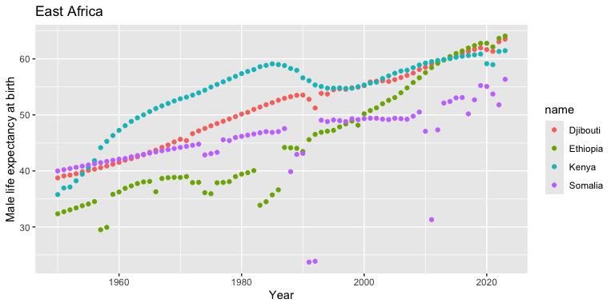

```r
ggplot(east_africa, aes(x = year, y = e0, color = name)) +
  geom_point() +
  labs(
    x = "Year",
    y = "Male life expectancy at birth",
    title = "East Africa"
  )
```

Next, fit the model with `hierarchical = TRUE` to estimate the double logistic parameters hierarchically across countries:

```r
fit_hier <- my_lifeplus(
  data = east_africa,
  transition_model = transition_model_double_logistic(hierarchical = TRUE),
  data_model = data_model_normal(),
  shock_model = shock_model_regularized_horseshoe(scale_global = 0.1)
)
```

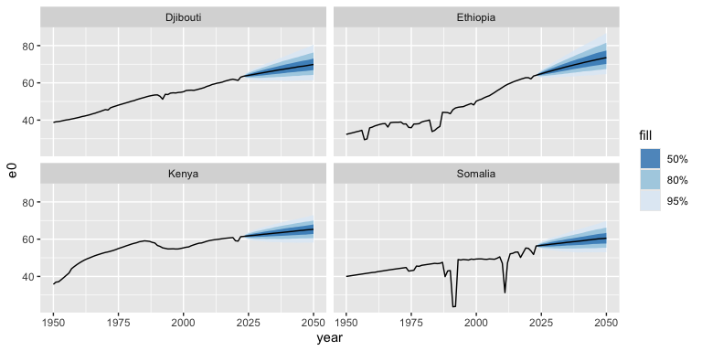

```r
plot_projections(fit_hier, data = FALSE)
```

We can also fit the model with `hierarchical = FALSE` to estimate the double logistic parameters separately in each country:

```r
fit_indep <- my_lifeplus(
  data = east_africa,
  transition_model = transition_model_double_logistic(hierarchical = FALSE),
  data_model = data_model_normal(),
  shock_model = shock_model_regularized_horseshoe(scale_global = 0.1)
)
```

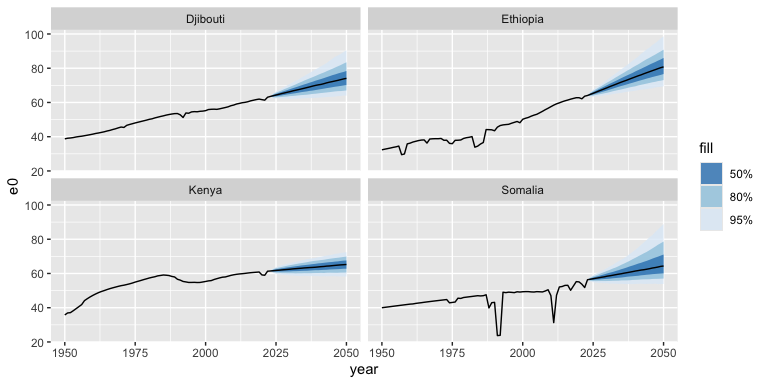

```r
plot_projections(fit_indep, data = FALSE)
```

## Working with results

The `tidy` method extracts posterior estimates as a tibble, making results easy to use with `dplyr` and `ggplot2`.

```r
tidy(fit_hier) |>
  dplyr::filter(area == "Somalia", time >= 2020) |>
  head(10)
```

```
#> # A tibble: 10 × 7
#>    term  area     time estimate conf.low conf.high conf.level
#>    <chr> <chr>   <dbl>    <dbl>    <dbl>     <dbl>      <dbl>
#>  1 life  Somalia  2020     55.1     55.1      55.1       0.95
#>  2 life  Somalia  2021     53.7     53.7      53.7       0.95
#>  3 life  Somalia  2022     51.8     51.8      51.8       0.95
#>  4 life  Somalia  2023     56.3     56.3      56.3       0.95
#>  5 life  Somalia  2024     56.5     55.2      57.9       0.95
#>  6 life  Somalia  2025     56.7     54.8      58.7       0.95
#>  7 life  Somalia  2026     56.8     54.5      59.3       0.95
#>  8 life  Somalia  2027     57.0     54.2      59.8       0.95
#>  9 life  Somalia  2028     57.2     54.1      60.4       0.95
#> 10 life  Somalia  2029     57.3     54.0      60.8       0.95
```

We can use this to easily develop custom visualizations. For example, let’s directly compare on the same plot the posterior median projections from East Africa with and without hierarchical estimation of the transition parameters:

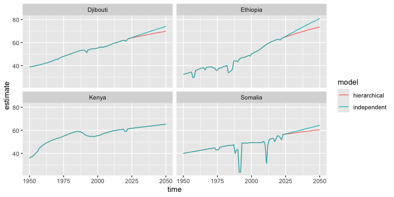

```r
dplyr::bind_rows(
  tidy(fit_hier) |> dplyr::mutate(model = "hierarchical"),
  tidy(fit_indep) |> dplyr::mutate(model = "independent")
) |>
  ggplot(aes(x = time, y = estimate, color = model)) +
  geom_line() +
  facet_wrap(~area)
```